# Exercise 11: Nonlinear Programming (Lagrange + KKT + SVM)

[Optimization in Machine Learning](https://slds-lmu.github.io/website_optimization/)

**Reproducibility**

Produced with Python 3.10 and R 4.4.1. To reproduce, install the pinned package versions below.

**Python**

```bash
pip install numpy==2.0.2 matplotlib==3.10.8 cvxpy==1.7.5
```

**R**

```r
install.packages("remotes")
remotes::install_version("CVXR", "1.8.2")
remotes::install_version("ggplot2", "3.5.1")
remotes::install_version("mlr3", "1.6.0")
```

## Problem 1: Lagrange multipliers

Solve the constrained optimization problem

$$\min_{(x, y) \in \mathbb{R}^2}\ x + 2y \quad \text{s.t.} \quad x^2 + 4 y^2 = 4$$

by Lagrange multipliers.

## Problem 2: Nonlinear SVM

We have $200$ binary observations from a *moons* distribution (two interleaved half-circles) — not linearly separable. The standard SVM trick: lift to a higher-dimensional feature space via $\phi: \mathbb{R}^d \to \mathbb{R}^l$ and learn a linear separator there. The primal soft-margin SVM in feature space is

$$\min_{\boldsymbol{\theta}, \theta_0, \boldsymbol{\zeta}}\ \tfrac{1}{2}\|\boldsymbol{\theta}\|^2 + C\sum_{i=1}^n \zeta^{(i)} \quad \text{s.t.} \quad y^{(i)}\!\left(\langle \boldsymbol{\theta}, \phi(\mathbf{x}^{(i)})\rangle + \theta_0\right) \geq 1 - \zeta^{(i)},\ \zeta^{(i)} \geq 0\ \forall i.$$

**R**

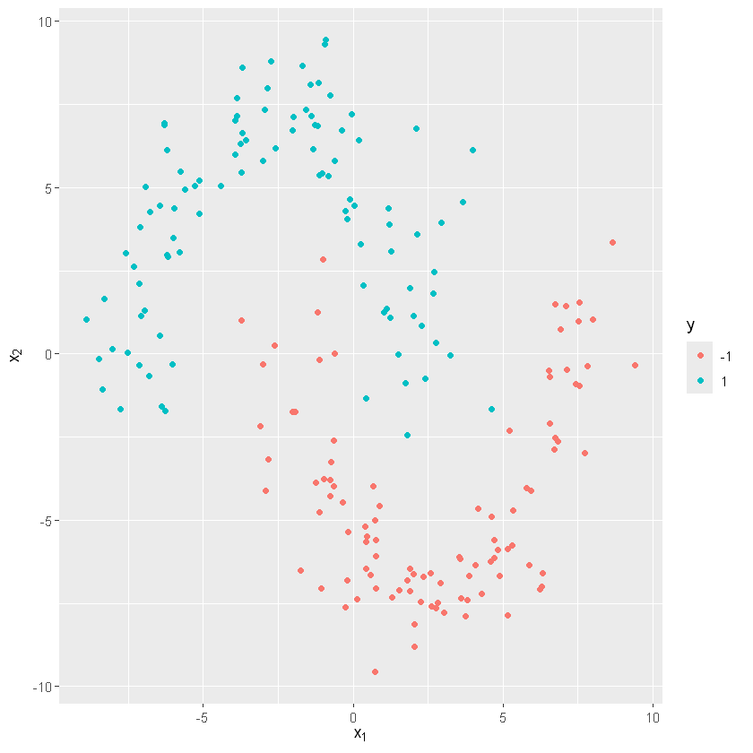

```r
library(ggplot2)
library(CVXR)

# 200 nonlinearly separable observations from a moons distribution.
moon_data <- read.csv("data/moons.csv")
n <- nrow(moon_data)
moon_data$y_dec <- as.factor(moon_data$y)

ggplot(moon_data, aes(x = x1, y = x2, color = y_dec)) +
  geom_point(size = 1.5) +
  xlab(expression(x[1])) + ylab(expression(x[2])) +
  labs(color = expression(y))
```

**Python**

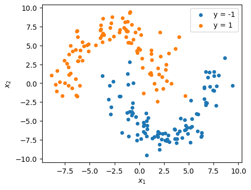

```python
import numpy as np
import matplotlib.pyplot as plt
import cvxpy as cp

# 200 nonlinearly separable observations from a moons distribution.
data = np.genfromtxt("data/moons.csv", delimiter=",", names=True)
X = np.column_stack([data["x1"], data["x2"]])
y = data["y"].astype(float)
n = X.shape[0]

fig, ax = plt.subplots(figsize=(5, 4))
for label in (-1, 1):
    mask = y == label
    ax.scatter(X[mask, 0], X[mask, 1], label=f"y = {label}", s=18)
ax.set_xlabel(r"$x_1$"); ax.set_ylabel(r"$x_2$")
ax.legend()
plt.show()
```

### (a) Lagrangian

Write down the Lagrangian of the nonlinear SVM.

### (b) Solve the primal SVM

Solve the primal nonlinear SVM with $C = 1$ and a third-order polynomial transformation (without intercept)

$$\phi(\mathbf{x}) = (x_1, x_2, x_1^2, x_2^2, x_1 x_2, x_1^2 x_2, x_1 x_2^2, x_1^3, x_2^3)^\top \in \mathbb{R}^9$$

using `CVXR` (R) or `cvxpy` (Python).

### (c) KKT conditions

State the KKT conditions of the general nonlinear SVM.

### (d) Dual form

Derive the dual form of the nonlinear SVM. State an advantage of the dual over the primal.

*Hint:* use the KKT conditions to eliminate the primal variables from the Lagrangian.

### (e) Solve the dual SVM

*Hint 1:* For a polynomial transformation $\phi$ of order $l$ (without intercept) there exists an invertible diagonal $\mathbf{D} \in \mathbb{R}^{l \times l}$ such that $\langle \mathbf{D}\phi(\mathbf{x}), \mathbf{D}\phi(\mathbf{z})\rangle = (\mathbf{x}^\top \mathbf{z}+ 1)^l - 1$.

*Hint 2:* Add $10^{-7} \mathbf{I}$ to the kernel matrix to ensure invertibility / positive-definiteness.